# Evaluating London’s Ultra Low Emission Zone: A Spatial Analysis of Air Quality Impacts

Sanskriti Jha and Alberto Marcos Fernandez

2025-03-25

## Introduction

In London – a city of nearly nine million residents – traffic on busy roads produces almost half of all air pollution, and about 4,000 Londoners per year are estimated to die prematurely due to long-term exposure to dirty air. Pollutants such as nitrogen oxides (NOx) and fine particulate matter (PM₂.₅) damage cardiovascular and respiratory health.

One policy response in many European cities has been the creation of low-emission zones (LEZs), which restrict or discourage high-polluting vehicles in designated areas. By setting emission standards and charging non-compliant vehicles, LEZs aim to curb traffic-related pollution at its source, thereby improving air quality in dense urban centers. London has been at the forefront of such interventions. The city introduced a pioneering **Congestion Charge** in 2003 to reduce traffic in the core, followed in 2008 by the **Low Emission Zone (LEZ)** covering Greater London (focused initially on heavy diesel vehicles). Building on these, in April 2019 London launched the **Ultra Low Emission Zone (ULEZ)** in central London, applying strict emissions standards to most vehicle types (not just heavy vehicles) and levying a daily charge on those that do not meet the standards.

The primary goal of the ULEZ is to accelerate the adoption of cleaner vehicles and reduce harmful pollutants like NO₂ in the city’s most trafficked areas. The ULEZ policy has clear public health motivations. Levels of NO₂ (nitrogen dioxide) at roadside monitoring stations have also dropped significantly. Notably, all monitoring sites along the ULEZ boundary recorded large NO₂ reductions (on the order of 19–27% compared to a no-ULEZ scenario), indicating that improvements were not confined to the city center

This evidence suggests the ULEZ did **not simply displace** traffic or pollution to the periphery; on the contrary, air quality improved even at the boundary of the zone, alleviating concerns about spatial spillover of dirty air.

## Motivation

Another motivation is to apply robust **causal inference methods** to strengthen the evidence on ULEZ effectiveness. One key technique is the **difference-in-differences (DiD)** approach, which compares changes in air pollution over time between areas affected by the policy (inside the ULEZ) and a control group of areas not subject to the ULEZ (outside the zone). In addition to DiD, our study is motivated to explore **spatial regression techniques** that account for distance to the ULEZ boundary. A **spillover regression** will explicitly test how changes in NO₂ concentrations relate to proximity to the zone border. t.

In summary, the motivations for this study include:

- **Causal Impact Assessment:** Quantifying the ULEZ’s effect on NO₂ levels using a difference-in-differences design to control for confounding factors, thus determining the policy’s true effectiveness.
- **Spatial Analysis of Spillovers:** Investigating how air quality improvements are distributed in space, particularly at the ULEZ boundaries, to detect any displacement of pollution or regional spillover benefits.

**Do urban low-emission zones work, how far do their benefits reach, and what lessons do they offer for sustainable urban development?**

# Step 1: Load Libraries and Spatial Data

This section introduces the Ultra Low Emission Zone (ULEZ) policy and outlines the data sources used for evaluation. We frame the research question in context: did the ULEZ improve air quality in London? To answer this, we gather air pollution measurements (e.g., NO₂ concentrations) from London’s monitoring network for periods before and after ULEZ implementation. The data are obtained via external sources (such as the London Air Quality data portal), demonstrating integration of outside data into our analysis (an API/web data retrieval step covered in class). This introductory step mirrors the Introduction and Data sections of a policy evaluation paper, establishing the problem significance (ULEZ was expected to cut pollution) and describing our raw dataset

```r
library(sf)
```

```r
library(ggplot2)
library(dplyr)
library(leaflet)
library(readr)
library(lubridate)
library(httr)
```

```r
# We first download the 2019 ULEZ from the London gov page
ulez_url <- "https://data.london.gov.uk/download/ultra_low_emissions_zone/936d71d8-c5fc-40ad-a392-6bec86413b48/CentralUltraLowEmissionZone.geojson"

geojson_file <- "CentralUltraLowEmissionZone.geojson"

GET(ulez_url, write_disk(geojson_file, overwrite = TRUE))
```

```
## Response [https://airdrive-secure.s3-eu-west-1.amazonaws.com/london/dataset/ultra_low_emissions_zone/2023-12-21T16%3A16%3A50/CentralUltraLowEmissionZone.geojson?X-Amz-Algorithm=AWS4-HMAC-SHA256&X-Amz-Credential=AKIAJJDIMAIVZJDICKHA%2F20250326%2Feu-west-1%2Fs3%2Faws4_request&X-Amz-Date=20250326T20…
##   Date: 2025-03-26 20:18
##   Status: 200
##   Content-Type: application/geo+json
##   Size: 57.8 kB
## <ON DISK>  C:\Users\Alberto\Downloads\CentralUltraLowEmissionZone.geojson
```

```r
ulez_2019 <- st_read(geojson_file, quiet = FALSE)
ulez_2019 <- st_transform(ulez_2019, crs = 4326)
```

```r
gla_boundary <- st_read("C:/Users/Alberto/Downloads/ULEZ Diff in Diff/ULEZ Diff in Diff/Shapefiles/Greater London Area/London_GLA_Boundary.shp")
ulez_2021 <- st_read("C:/Users/Alberto/Downloads/ULEZ Diff in Diff/ULEZ Diff in Diff/Shapefiles/ULEZ_2021/InnerUltraLowEmissionZone.shp")
gla_boundary <- st_transform(gla_boundary, crs = 4326)
ulez_2019 <- st_transform(ulez_2019, crs = 4326)
ulez_2021 <- st_transform(ulez_2021, crs = 4326)
```

```r
# Create leaflet map
leaflet() %>%
  addProviderTiles("OpenStreetMap.Mapnik") %>%
  addPolygons(data = gla_boundary, color = "#006400", weight = 2, fillOpacity = 0.15, label = "GLA Boundary") %>%
  addPolygons(data = ulez_2021, color = "#32CD32", weight = 2, fillOpacity = 0.3, label = "ULEZ 2021") %>%
  addPolygons(data = ulez_2019, color = "#B22222", weight = 2, fillOpacity = 0.4, label = "ULEZ 2019") %>%
  addLegend(position = "bottomright", colors = c("#006400", "#32CD32", "#B22222"),
            labels = c("GLA Boundary", "ULEZ 2021", "ULEZ 2019"), title = "Zones")
```

[interactive chart not shown]

# Step 2: Download the Air Quality data from the aqicn.org API

```r
# Load necessary libraries
library(httr)      # For making API requests
library(jsonlite)  # For parsing JSON

# Your AQICN API Token (Replace with your actual token)
api_key <- "c60ca5d14b5b6d2408a092c8045832a3d7faecdb"

# Define the bounding box for Greater London
lat_min <- 51.3
lat_max <- 51.7
lon_min <- -0.5
lon_max <- 0.5
bbox <- paste0(lat_min, ",", lon_min, ",", lat_max, ",", lon_max)

# Construct the API request URL
url <- paste0("https://api.waqi.info/map/bounds/?latlng=", bbox, "&token=", api_key)

# Send GET request to the API
response <- GET(url)

# Parse the response
data <- fromJSON(content(response, "text"))$data

stations_sf <- st_as_sf(data, coords = c("lon", "lat"), crs = 4326)
```

Now we add the air quality stations location on the leaflet. With that our Spatial setting is complete. We have the two ULEZ setting configurations and the stations scattered inside and outside both iterations of the policy as well as London Greater Area.

```r
leaflet() %>%
  addProviderTiles("OpenStreetMap.Mapnik") %>%

  # GLA boundary
  addPolygons(data = gla_boundary, color = "#006400", weight = 2, fillOpacity = 0.15, label = "GLA Boundary") %>%

  # ULEZ 2021
  addPolygons(data = ulez_2021, color = "#32CD32", weight = 2, fillOpacity = 0.3, label = "ULEZ 2021") %>%

  # ULEZ 2019
  addPolygons(data = ulez_2019, color = "#B22222", weight = 2, fillOpacity = 0.4, label = "ULEZ 2019") %>%

  # Add station points
  addCircleMarkers(data = stations_sf,
                   radius = 2,
                   color = "#FF8C00",
                   stroke = TRUE,
                   fillOpacity = 0.5,
                   label = ~paste("Station UID:", uid)) %>%

  # Legend
  addLegend(position = "bottomright",
            colors = c("#006400", "#32CD32", "#B22222"),
            labels = c("GLA Boundary", "ULEZ 2021", "ULEZ 2019"),
            title = "Zones")
```

[interactive chart not shown]

# Step 3: Download historical data from the website

Unfortunately, the API is still in development so we had to manually download the historical data. Currently, the API can only provide real-time data (see snippet above), the historical data is yet to be implemented.

We define a matching function to select the stations for which we have sufficient data. There where some very recent stations that were installed in 2025 and cannot be used to estimate the Diff in Diff model.

```r
library(stringdist)

# Function to clean the filenames
clean_filename <- function(filename) {
  filename %>%
    gsub("-air-quality\\.csv$", "", .) %>%  # To remove suffix
    gsub("--", " - ", .)  # Replace "--" with " - "
}

# Function to find best match
match_station_names <- function(station_names, csv_files) {
  # Clean CSV filenames
  csv_cleaned <- sapply(csv_files, clean_filename)

  # Create a data frame to store matches
  match_results <- data.frame(csv_file = csv_files, station_name = NA, match_score = NA)

  # Find the best match for each CSV file
  for (i in seq_along(csv_cleaned)) {
    # Compute string distance to all station names
    distances <- stringdist::stringdist(csv_cleaned[i], station_names, method = "lv")

    # Get the best match
    best_match_idx <- which.min(distances)
    match_results$station_name[i] <- station_names[best_match_idx]
    match_results$match_score[i] <- distances[best_match_idx]  # Lower score = better match
  }

  return(match_results)
}


csv_files <- list.files("C:/Users/Alberto/Downloads/ULEZ Diff in Diff/ULEZ Diff in Diff/CSV", pattern = "*.csv", full.names = FALSE)
data_name <- data$station  # Assuming dataframe column

# Get matches
matches <- match_station_names(data_name[,1], csv_files)

print(matches)
```

```
##                                                                   csv_file
## 1                  bexley-- belvedere west, united kingdom-air-quality.csv
## 2     brent-- ark franklin primary academy, united kingdom-air-quality.csv
## 3                             brent-- ikea, united kingdom-air-quality.csv
## 4        brent-- john keble primary school, united kingdom-air-quality.csv
## 5                     brent-- neasden lane, united kingdom-air-quality.csv
## 6                     camden-- euston road, united kingdom-air-quality.csv
## 7                          camden-kerbside, united kingdom-air-quality.csv
## 8           greenwich-- a206 burrage grove, united kingdom-air-quality.csv
## 9            greenwich-- john harrison way, united kingdom-air-quality.csv
## 10       greenwich-- plumstead high street, united kingdom-air-quality.csv
## 11 greenwich-- trafalgar road (hoskins st), united kingdom-air-quality.csv
## 12            greenwich-- westhorne avenue, united kingdom-air-quality.csv
## 13            greenwich-- woolwich flyover, united kingdom-air-quality.csv
## 14                       haringey-roadside, united kingdom-air-quality.csv
```

[output cut: 47 more lines]

We construct a dummy to check whether the stations are inside the 2019 and 2021 ULEZs

```r
# For the 2019 ULEZ
data_2 <- data[data$station$name %in% matches$station_name, ]

# 1. Convert data_2 to an sf object using coordinates
data_2 <- st_as_sf(data_2, coords = c("lon", "lat"), crs = 4326)

# 2. Ensure both sf objects use the same CRS
data_2 <- st_transform(data_2, crs = st_crs(ulez_2019))

# 3. Determine if each point is inside the ULEZ polygon
data_2$in_ulez_2019 <- st_within(data_2, ulez_2019, sparse = FALSE)[, 1]
```

```r
# We repeat for the 2021 ULEZ edition
data_2 <- st_as_sf(data_2, coords = c("lon", "lat"), crs = 4326)

data_2 <- st_transform(data_2, crs = st_crs(ulez_2021))

data_2 <- data_2 %>%
  mutate(in_ulez_2021 = st_within(., ulez_2021, sparse = FALSE)[, 1])
```

We create an enriched data set that includes all the historical information of the selected air quality detectors.

```r
# Define path to CSV folder
csv_folder <- "C:/Users/Alberto/Downloads/ULEZ Diff in Diff/ULEZ Diff in Diff/CSV"

# Create list of merged data frames
merged_list <- lapply(seq_len(nrow(matches)), function(i) {
  # Extract file name and matching station name
  file_name <- matches$csv_file[i]
  station_name <- matches$station_name[i]

  # Full file path
  full_path <- file.path(csv_folder, file_name)

  # Read the CSV
  if (!file.exists(full_path)) return(NULL)  # Skip if file missing
  df <- read_csv(full_path, show_col_types = FALSE)

  # Match metadata from data_2
  station_info <- data_2 %>%
    filter(station$name == station_name)

  # If we find the station, bind metadata
  if (nrow(station_info) == 1) {
    df <- df %>%
      mutate(
        station_name = station_name,
        lat = station_info$lat,
        lon = station_info$lon,
        uid = station_info$uid,
        api_aqi = station_info$aqi,
        in_ulez_2019 = station_info$in_ulez_2019,
        in_ulez_2021 = station_info$in_ulez_2021
      )
  }

  return(df)
})

# Bind all into one dataframe
enriched_air_quality_data <- bind_rows(merged_list)
```

# Step 4: Evolution of the problematic

To understand how the problem of air pollution has evolved across time and space in Greater London, we begin by visualizing interpolated PM2.5 concentration surfaces for each year. These spatial representations help identify broad patterns and highlight areas with persistently high or improving air quality. To streamline this process and ensure consistency across years, we define a reusable function that generates the interpolated PM2.5 raster surface for any given year. This allows us to efficiently compare pollution levels across time, while laying the groundwork for more rigorous causal analysis.

```r
plot_pm25_surface <- function(year_input) {
  library(gstat)
  library(sp)
  library(raster)
  library(sf)
  library(dplyr)
  library(lubridate)

  sf::sf_use_s2(FALSE)  # Disable s2 for union compatibility

  # Filter and average PM2.5
  aq_year <- enriched_air_quality_data %>%
    mutate(date = ymd(date)) %>%
    filter(year(date) == year_input, !is.na(pm25)) %>%
    group_by(uid) %>%
    summarise(avg_pm25 = mean(pm25, na.rm = TRUE), .groups = "drop") %>%
    left_join(data_2 %>% dplyr::select(uid, geometry), by = "uid") %>%
    st_as_sf(sf_column_name = "geometry", crs = st_crs(data_2))

  # Spatial conversion
  aq_sp <- as(aq_year, "Spatial")

  # Expanded bounding box
  combined_bounds <- st_union(st_combine(c(
    st_geometry(ulez_2019),
    st_geometry(ulez_2021),
    st_geometry(gla_boundary),
    st_geometry(aq_year)
  )))

  bbox <- st_bbox(combined_bounds)
  bbox_expanded <- bbox
  bbox_expanded[c("xmin", "ymin")] <- bbox[c("xmin", "ymin")] - 0.02
  bbox_expanded[c("xmax", "ymax")] <- bbox[c("xmax", "ymax")] + 0.02

  grd <- raster(xmn = bbox_expanded["xmin"],
                xmx = bbox_expanded["xmax"],
                ymn = bbox_expanded["ymin"],
                ymx = bbox_expanded["ymax"],
                resolution = 0.01)

  grd_sp <- as(grd, "SpatialPixelsDataFrame")
  proj4string(grd_sp) <- proj4string(aq_sp)

  # Interpolation
  idw_result <- idw(avg_pm25 ~ 1, aq_sp, newdata = grd_sp, idp = 2)
  idw_raster <- raster(idw_result)

  cols <- colorRampPalette(c("green", "yellow", "red", "darkred"))(50)


  plot(idw_raster,
       main = paste("Interpolated PM2.5 Surface (", year_input, ", IDW)", sep = ""),
       col = cols,
       zlim = c(25, 65),
       legend.args = list(text = "PM2.5 (µg/m³)", side = 4, font = 2, line = 2.5, cex = 0.8))

  points(aq_sp, col = "darkred", pch = 16)

  plot(st_geometry(st_transform(gla_boundary, crs = st_crs(data_2))),
       add = TRUE, border = "darkgreen", lwd = 2)
  plot(st_geometry(st_transform(ulez_2019, crs = st_crs(data_2))),
       add = TRUE, border = "darkgreen", lwd = 2)
  plot(st_geometry(st_transform(ulez_2021, crs = st_crs(data_2))),
       add = TRUE, border = "darkgreen", lwd = 2)
}
```

```
## Spherical geometry (s2) switched off
```

```
## although coordinates are longitude/latitude, st_union assumes that they are
## planar
```

```
## [inverse distance weighted interpolation]
```

```
## although coordinates are longitude/latitude, st_union assumes that they are
## planar
```

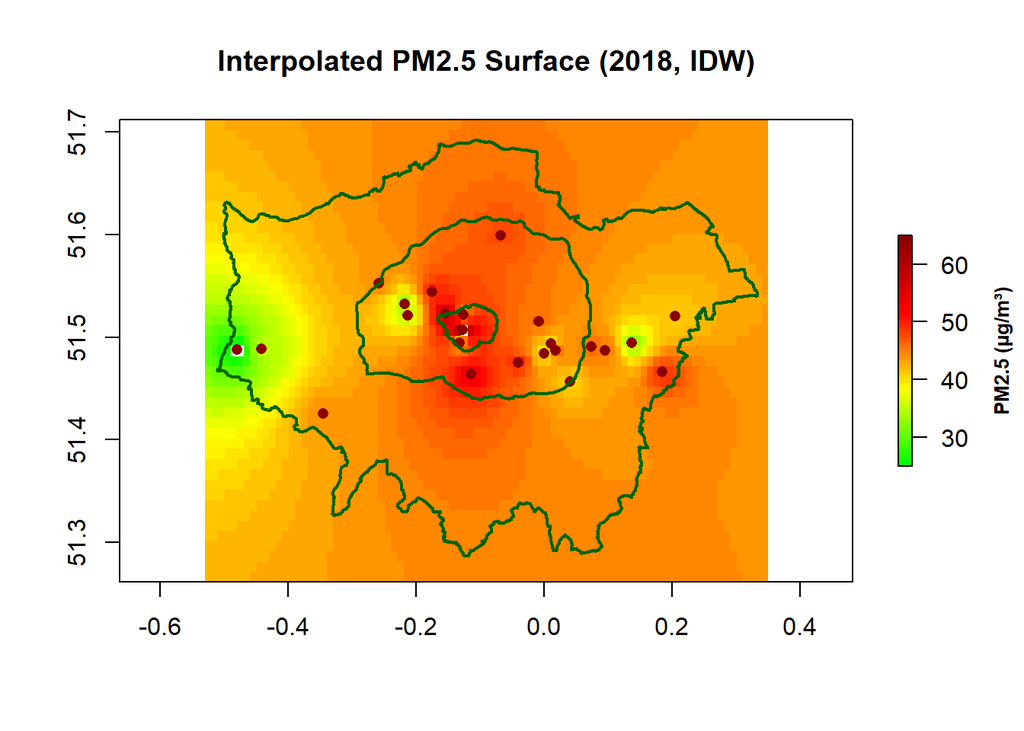

```
## [inverse distance weighted interpolation]
```

```
## although coordinates are longitude/latitude, st_union assumes that they are
## planar
```

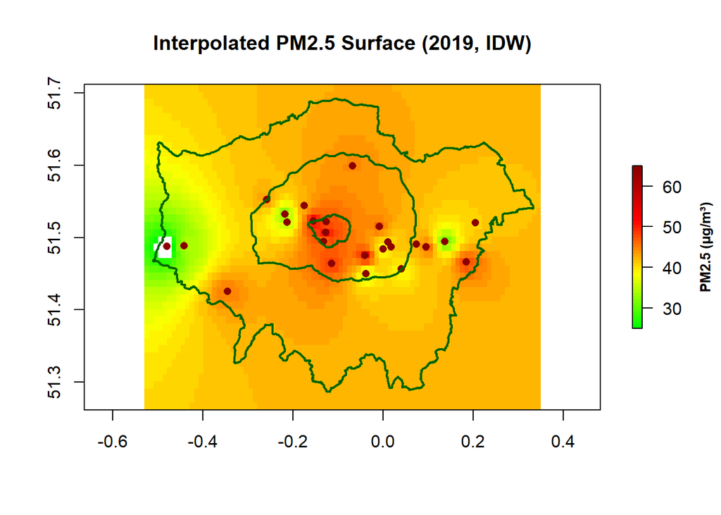

```
## [inverse distance weighted interpolation]
```

```
## although coordinates are longitude/latitude, st_union assumes that they are
## planar
```

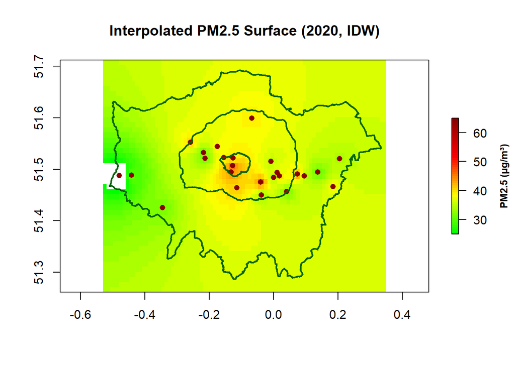

```
## [inverse distance weighted interpolation]
```

```
## although coordinates are longitude/latitude, st_union assumes that they are
## planar
```

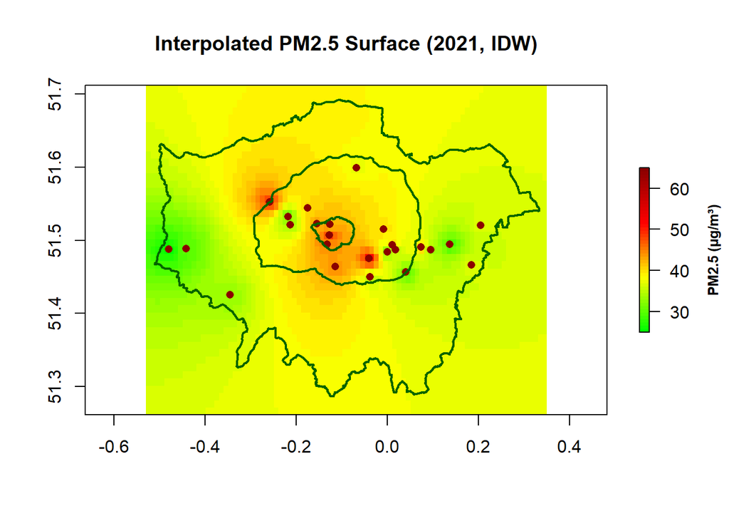

```
## [inverse distance weighted interpolation]
```

```
## although coordinates are longitude/latitude, st_union assumes that they are
## planar
```

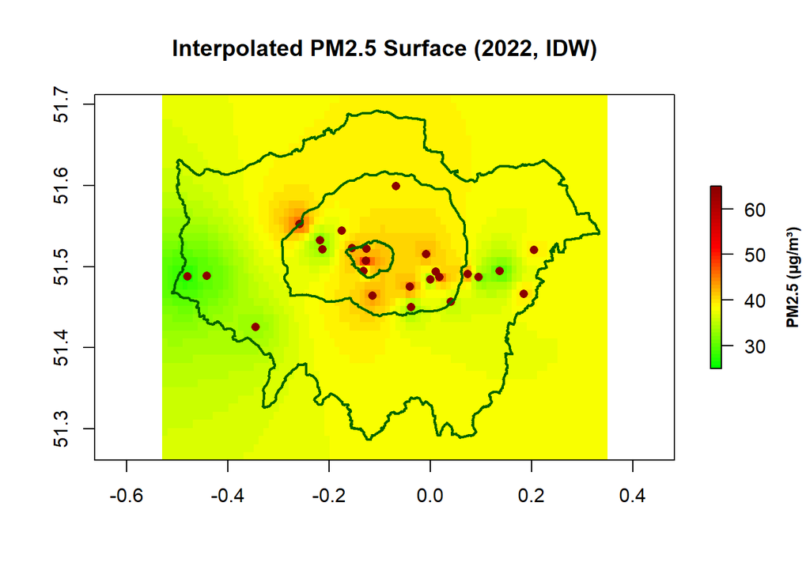

```
## [inverse distance weighted interpolation]
```

```
## although coordinates are longitude/latitude, st_union assumes that they are
## planar
```

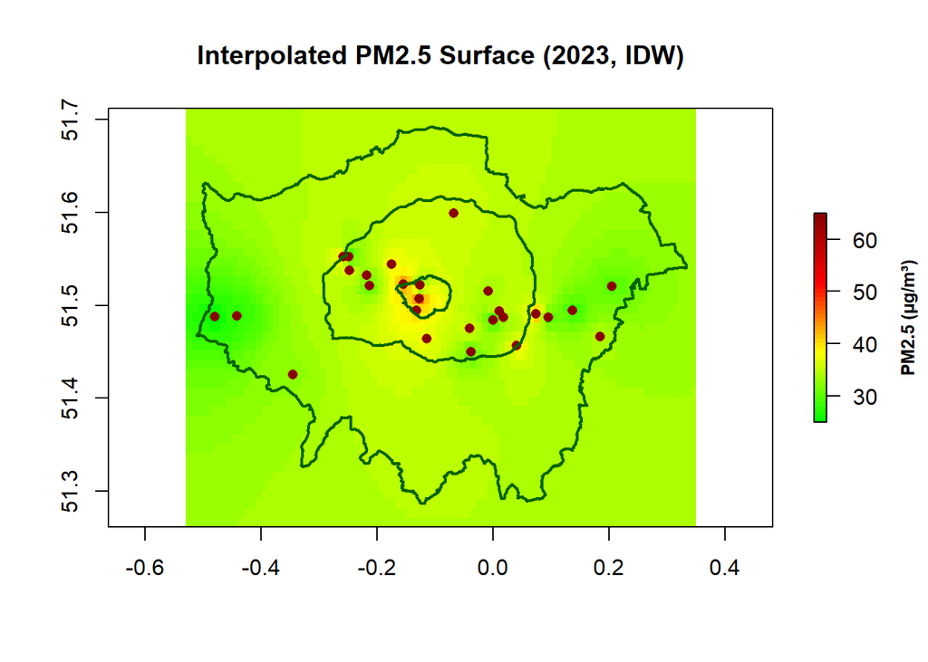

```
## [inverse distance weighted interpolation]
```

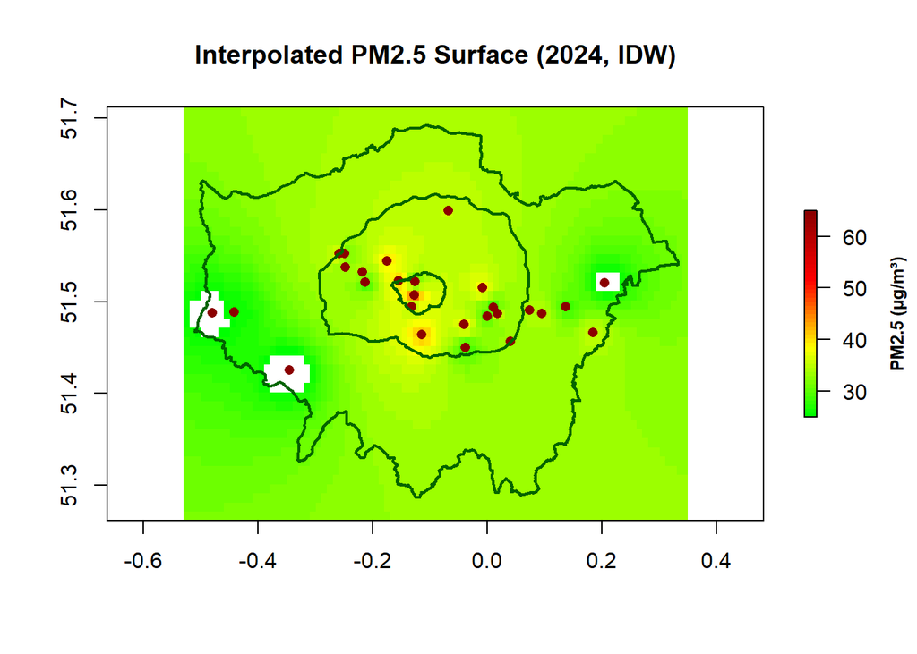

```r
for (year in 2018:2024){
plot_pm25_surface((year))
}
```

While the sequence of interpolated PM2.5 surfaces suggests a gradual decline in pollution levels over time, this observed trend may be driven by a variety of overlapping factors. Broader time trends such as the progressive electrification of the vehicle fleet, regulatory changes, seasonal variability, or fixed characteristics of London itself could all contribute to this reduction. Therefore, a simple visual analysis cannot attribute causality to any specific policy intervention. To isolate the effect of the Ultra Low Emission Zone (ULEZ) expansions from other confounding influences, we adopt a Differences-in-Differences (DiD) approach, which allows us to estimate the policy impact by comparing treated and untreated areas over time.

```r
# Create a color column based on ULEZ inclusion
data_2 <- data_2 %>%
  mutate(zone_status = case_when(
    in_ulez_2019 ~ "ULEZ 2019",
    in_ulez_2021 & !in_ulez_2019 ~ "ULEZ 2021 only",
    TRUE ~ "Outside ULEZ"
  ))


data_2 <- data_2 %>%
  mutate(color = case_when(
    zone_status == "ULEZ 2019" ~ "#B22222",        # red
    zone_status == "ULEZ 2021 only" ~ "#32CD32",   # lime green
    zone_status == "Outside ULEZ" ~ "#FF8C00"      # orange
  ))


leaflet() %>%
  addProviderTiles("OpenStreetMap.Mapnik") %>%

  # GLA boundary
  addPolygons(data = gla_boundary, color = "#006400", weight = 2, fillOpacity = 0.15, label = "GLA Boundary") %>%

  # ULEZ polygons
  addPolygons(data = ulez_2021, color = "#32CD32", weight = 2, fillOpacity = 0.3, label = "ULEZ 2021") %>%
  addPolygons(data = ulez_2019, color = "#B22222", weight = 2, fillOpacity = 0.4, label = "ULEZ 2019") %>%

  # Station points
  addCircleMarkers(data = data_2,
                   radius = 4,
                   color = ~color,
                   stroke = TRUE,
                   fillOpacity = 0.7,
                   label = ~paste("Station:", station$name)) %>%


  addLegend(position = "bottomright",
            colors = c("#B22222", "#32CD32", "#FF8C00"),
            labels = c("ULEZ 2019", "ULEZ 2021 only", "Outside ULEZ"),
            title = "Station Zone")
```

[interactive chart not shown]

# Step 5: Differences-in-Differences parallel trends assumption test

In order to perform the Differences-in-Differences analysis we have to check if the “Parallel Trends” before the implementation of the ULEZ on October 21, 2021.

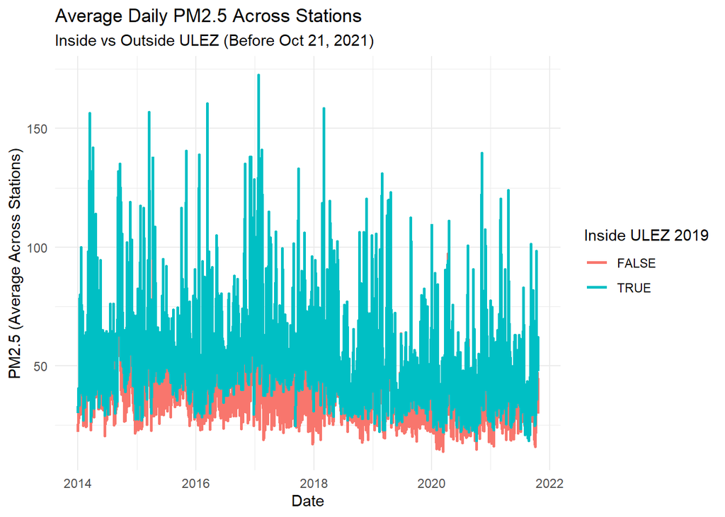

```r
# Filter for dates before ULEZ 2021 expansion (Oct 21, 2021)
enriched_air_quality_data_filtered <- enriched_air_quality_data %>%
  filter(as.Date(date) < as.Date("2021-10-21"))

# First, average per station per day
station_daily_pm25 <- enriched_air_quality_data_filtered %>%
  group_by(date, station_name, in_ulez_2019) %>%
  summarise(pm25_station_avg = mean(pm25, na.rm = TRUE), .groups = "drop")

# Then, average across stations per day for each group
pm25_group_avg <- station_daily_pm25 %>%
  group_by(date, in_ulez_2019) %>%
  summarise(avg_pm25 = mean(pm25_station_avg, na.rm = TRUE), .groups = "drop")


ggplot(pm25_group_avg, aes(x = as.Date(date), y = avg_pm25, color = in_ulez_2019)) +
  geom_line(size = 1) +
  labs(
    title = "Average Daily PM2.5 Across Stations",
    subtitle = "Inside vs Outside ULEZ (Before Oct 21, 2021)",
    x = "Date",
    y = "PM2.5 (Average Across Stations)",
    color = "Inside ULEZ 2019"
  ) +
  theme_minimal()
```

Preliminary visual inspection suggests that the trends in PM2.5 levels for stations inside and outside the ULEZ 2019 zone are broadly parallel over time, with consistently higher average concentrations observed within the ULEZ area. However, due to the high variability and dispersion in the data, we formally test the parallel trends assumption by estimating a linear regression model that includes time, ULEZ status, and their interaction. A statistically insignificant interaction term would indicate no differential trend between the groups prior to the intervention, thereby supporting the validity of a DiD framework.

```r
data_3 <- enriched_air_quality_data %>%
  mutate(date = ymd(date))  # lubridate handles flexible formats

# Filter to pre-treatment period
pre_data <- data_3 %>%
  filter(date < as.Date("2019-04-08"))

# Create time variable (days since first date)
pre_data <- pre_data %>%
  mutate(time = as.numeric(date - min(date)))


pre_data <- pre_data %>%
  filter(!is.na(pm25), !is.na(in_ulez_2019))

#  Fit linear model with interaction
model <- lm(pm25 ~ time * in_ulez_2019, data = pre_data)

summary(model)
```

```
##
## Call:
## lm(formula = pm25 ~ time * in_ulez_2019, data = pre_data)
##
## Residuals:
##    Min     1Q Median     3Q    Max
## -51.89 -15.82  -3.66  10.45 361.78
##
## Coefficients:
##                         Estimate Std. Error t value Pr(>|t|)
## (Intercept)           48.7440074  0.3170335 153.750   <2e-16 ***
## time                  -0.0027098  0.0002561 -10.581   <2e-16 ***
## in_ulez_2019TRUE      11.3584963  0.7968948  14.253   <2e-16 ***
## time:in_ulez_2019TRUE -0.0006596  0.0006701  -0.984    0.325
## ---
## Signif. codes:  0 '***' 0.001 '**' 0.01 '*' 0.05 '.' 0.1 ' ' 1
##
## Residual standard error: 22.81 on 34760 degrees of freedom
## Multiple R-squared:  0.02736,    Adjusted R-squared:  0.02728
## F-statistic:   326 on 3 and 34760 DF,  p-value: < 2.2e-16
```

The fact that we cannot reject the `time:in_ulez_2019TRUE` at any confidence level supports the parallel trends assumption. In other words, the Diff-in-Diff analysis seems suited for this case of study.

# Step 6: Differences-in-Differences Estimation

We start with a basic DiD model to estimate the effect of the original ULEZ, which was introduced in April 2019. The model is:

pm_it = β₀ + β₁ · post_t + β₂ · treated_i + β₃ · (post_t × treated_i) + ε_it

- `pm_it` is the concentration of PM₂.₅ (fine particulate matter) at monitoring station *i* at time *t*.
- `post_t` is a binary variable equal to 1 for dates after **April 8, 2019**, and 0 before.
- `treated_i` is a binary variable indicating whether station *i* is inside the 2019 ULEZ boundary.
- `post_t × treated_i` is the interaction term that captures the combined effect of being treated and being in the post-treatment period.
- `β₃` is the main coefficient of interest—it represents the estimated effect of the ULEZ policy on pollution levels.
- `ε_it` is the error term, capturing unexplained variation.

```r
did_data <- enriched_air_quality_data %>%
  mutate(
    date = ymd(date),
    post = date >= as.Date("2019-04-08"),            # Indicator for post-policy period
    treated = in_ulez_2019                           # TRUE if station is in ULEZ 2019
  ) %>%
  filter(!is.na(pm25), !is.na(treated))

# Estimate DiD regression
model_did <- lm(pm25 ~ post * treated, data = did_data)


summary(model_did)
```

```
##
## Call:
## lm(formula = pm25 ~ post * treated, data = did_data)
##
## Residuals:
##    Min     1Q Median     3Q    Max
## -48.63 -14.06  -4.06   9.31 505.94
##
## Coefficients:
##                      Estimate Std. Error t value Pr(>|t|)
## (Intercept)           45.6861     0.1192  383.28   <2e-16 ***
## postTRUE              -9.6222     0.1520  -63.28   <2e-16 ***
## treatedTRUE           10.9392     0.3459   31.62   <2e-16 ***
## postTRUE:treatedTRUE  -4.8811     0.4436  -11.00   <2e-16 ***
## ---
## Signif. codes:  0 '***' 0.001 '**' 0.01 '*' 0.05 '.' 0.1 ' ' 1
##
## Residual standard error: 20.86 on 89992 degrees of freedom
## Multiple R-squared:  0.0683, Adjusted R-squared:  0.06827
## F-statistic:  2199 on 3 and 89992 DF,  p-value: < 2.2e-16
```

Can we know if the effects of estimated where subjected to spillover effects? What if by implementing the ULEZ the London municipal authority just diverted the traffic just outside the limits of the restricted area? In order to proxy for this effect we have run a regression on the effect that the variable distance with respect to the ULEZ (of the stations outside the ULEZ) had before and after the treatment was administered.

```r
library(lwgeom)
data_2 <- data_2 %>%
  mutate(distance_to_ulez = as.numeric(st_distance(geometry, ulez_2019)))

# Join with enriched dataset and convert date
data_spill <- enriched_air_quality_data %>%
  mutate(date = ymd(date)) %>%
  left_join(
    data_2 %>%
      sf::st_drop_geometry() %>%
      dplyr::select(uid, distance_to_ulez, in_ulez_2019),
    by = "uid"
  ) %>%
  filter(!is.na(pm25), !is.na(distance_to_ulez), in_ulez_2019.x == FALSE)

#Define pre- and post-policy windows
pre_data <- data_spill %>%
  filter(date < as.Date("2019-04-08"))

post_data <- data_spill %>%
  filter(date >= as.Date("2019-04-08") & date < as.Date("2021-10-21"))

# Estimate separate regressions
model_pre <- lm(pm25 ~ distance_to_ulez, data = pre_data)
model_post <- lm(pm25 ~ distance_to_ulez, data = post_data)


summary(model_pre)
```

```
##
## Call:
## lm(formula = pm25 ~ distance_to_ulez, data = pre_data)
##
## Residuals:
##    Min     1Q Median     3Q    Max
## -48.42 -14.97  -4.13   9.35 368.91
##
## Coefficients:
##                    Estimate Std. Error t value Pr(>|t|)
## (Intercept)       5.342e+01  2.250e-01  237.45   <2e-16 ***
## distance_to_ulez -7.414e-04  1.786e-05  -41.52   <2e-16 ***
## ---
## Signif. codes:  0 '***' 0.001 '**' 0.01 '*' 0.05 '.' 0.1 ' ' 1
##
## Residual standard error: 22.07 on 30634 degrees of freedom
## Multiple R-squared:  0.05329,    Adjusted R-squared:  0.05325
## F-statistic:  1724 on 1 and 30634 DF,  p-value: < 2.2e-16
```

```r
summary(model_post)
```

```
##
## Call:
## lm(formula = pm25 ~ distance_to_ulez, data = post_data)
##
## Residuals:
##    Min     1Q Median     3Q    Max
## -36.50 -12.95  -4.67   7.97 500.91
##
## Coefficients:
##                    Estimate Std. Error t value Pr(>|t|)
## (Intercept)       4.109e+01  2.401e-01  171.16   <2e-16 ***
## distance_to_ulez -4.220e-04  2.041e-05  -20.67   <2e-16 ***
## ---
## Signif. codes:  0 '***' 0.001 '**' 0.01 '*' 0.05 '.' 0.1 ' ' 1
##
## Residual standard error: 19.63 on 21409 degrees of freedom
## Multiple R-squared:  0.01957,    Adjusted R-squared:  0.01952
## F-statistic: 427.3 on 1 and 21409 DF,  p-value: < 2.2e-16
```

We can observe that the coefficient for distance is negative and significant across both models. However, one can notice that in the post treatment period, distance is less negative. This would be in line with the spillover (traffic redirection) hypothesis. In order to test whether this difference is significant we have conducted a z-statistic test on the two coefficients.

```r
b1 <- coef(summary(model_pre))["distance_to_ulez", "Estimate"]
se1 <- coef(summary(model_pre))["distance_to_ulez", "Std. Error"]

b2 <- coef(summary(model_post))["distance_to_ulez", "Estimate"]
se2 <- coef(summary(model_post))["distance_to_ulez", "Std. Error"]


z <- (b1 - b2) / sqrt(se1^2 + se2^2)

p_value <- 2 * (1 - pnorm(abs(z)))

cat("Z =", round(z, 3), "\n")
```

```
## Z = -11.778
```

```r
cat("p-value =", signif(p_value, 4), "\n")
```

```
## p-value = 0
```

The coefficients are significantly different. Therefore, it would be advisable to control for traffic data in future investigations.

# Step 7: Differences-in-Differences with a twist, Staggered DiD

This is an event-study type model, which estimates the effect relative to each location’s own treatment date:

pm_it = Σ (γ_k · 1[event_time_it = k]) + α_i + λ_t + ε_it for all k ≠ -1

- `event_time_it = t - treat_date_i` is the number of months relative to when station *i* was affected by the policy.
- `γ_k` represents the estimated effect *k* months before or after the treatment date.
- `α_i` are fixed effects for each monitoring station (to control for location-specific, time-invariant characteristics).
- `λ_t` are fixed effects for each time period (to control for common time shocks).
- The month immediately before treatment (k = –1) is left out as the **reference period**, so all estimates are relative to that time.

```r
library(fixest)

data_did_monthly <- enriched_air_quality_data %>%
  mutate(date = ymd(date)) %>%
  mutate(month = floor_date(date, "month")) %>%
  group_by(uid, month) %>%
  summarise(pm25 = mean(pm25, na.rm = TRUE), .groups = "drop") %>%
  rename(date = month) %>%

  #  Join treatment group info from spatial data (data_2)
  left_join(data_2 %>%
              dplyr::select(uid, zone_status), by = "uid") %>%

  #  Assign treatment dates based on ULEZ membership
  mutate(treat_date = case_when(
    zone_status == "ULEZ 2019" ~ as.Date("2019-04-01"),
    zone_status == "ULEZ 2021 only" ~ as.Date("2021-10-01"),
    TRUE ~ NA_Date_
  ))

data_did_monthly <- data_did_monthly %>%
  mutate(
    date = floor_date(date, "month"),
    treat_date = floor_date(treat_date, "month")
  )

model_staggered <- feols(
  pm25 ~ sunab(treat_date, date, ref.p = -1),
  data = data_did_monthly,
  fixef = c("uid", "date")
)
```

```
## NOTE: 1,413 observations removed because of NA values (LHS: 320, RHS: 1,128).
```

```
## The variables 'date::-63:cohort::2019-04-01', 'date::-62:cohort::2019-04-01', 'date::-61:cohort::2019-04-01', 'date::-60:cohort::2019-04-01', 'date::-59:cohort::2019-04-01', 'date::-58:cohort::2019-04-01' and 128 others have been removed because of collinearity (see $collin.var).
```

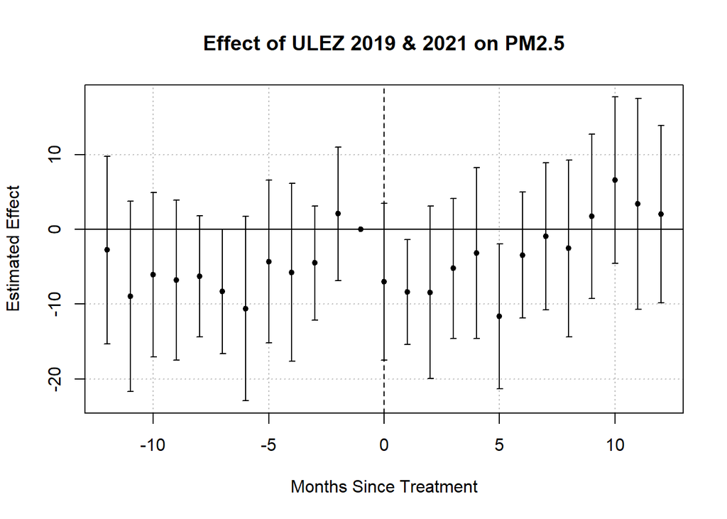

```r
iplot(model_staggered,
      ref.line = 0,
      keep = "-?1[0-2]$|^-?[0-9]$",  # Regex: -12 to +12
      main = "Effect of ULEZ 2019 & 2021 on PM2.5",
      xlab = "Months Since Treatment",
      ylab = "Estimated Effect")
```

# Step 8: Results and Conclusions

### Main Findings

The standard DiD regression estimates the average treatment effect of the 2019 ULEZ policy. The interaction term of interest (`postTRUE:treatedTRUE`) yields a statistically significant coefficient of **–4.88** (p < 2e–16), indicating that PM₂.₅ concentrations decreased by approximately **4.88 µg/m³** in treated areas relative to untreated areas following implementation. The model also reveals that treated areas had higher baseline pollution (`treatedTRUE = 10.94`) and that there was a general post-policy decline across all sites (`postTRUE = –9.62`), but the interaction isolates the effect directly attributable to the policy.

### Interpretation and Future Directions

However, there remains **room for improvement**. Notably, the fact that the **distance coefficient** becomes **less negative** suggests potential **spatial spillover effects**—i.e., pollution or traffic being displaced to areas just outside the ULEZ boundaries. This implies that while pollution decreased within the zone, some of it may have been redistributed rather than eliminated. Addressing this issue would require a deeper understanding of **traffic rerouting behavior**, which cannot be captured with pollution data alone. Incorporating **high-resolution traffic flow data** represents a valuable avenue for future research to evaluate the full system-wide effects of emission-based policies.